# Experience of Physical Violence among Women in Namibia

Findings from the 2013 Namibia Demographic and Health Survey

Ester Nepolo

Jan 16, 2023

# Introduction

Physical violence is a form of Domestic violence, characterised mostly by physical aggression such as hitting, kicking, biting, shoving, restraining, slapping, or throwing objects. This report presents findings from the 2013 Namibia Health and Demographic Survey, on the experience of physical violence among women age 15 - 49. The report presents the prevalence and distribution of physical violence by background characteristics.

# Prevalence of Physical violence

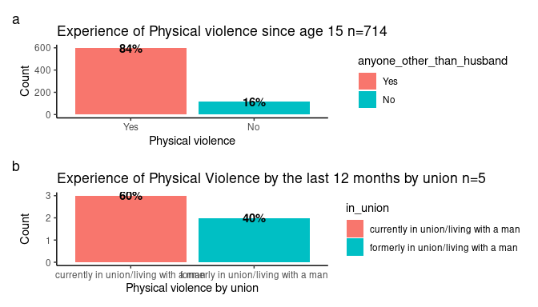

Figure 1: Distribution of physical violence among surveyed women.

As presented in figure 1 above, among the women age 15 - 49 that experienced physical violence since the age 15, the majority (84 percent) were violated/hurt by anyone other than their husbands or partners. Among those that experienced physical violence in 12 months preceding the survey, the majority (60 percent) were currently in union or living with a man.

## Physical Violence by background characteristics

Experience of physical violence varies substantially by background characteristics. As per Figure 2 below, older women (women between 25 and 49 years were more likely to experience physical violence compared to Adolescent Girls and Young Women. Women with less than five children were more likely to experience physical violence compared to those women without children or those women with five or more children.

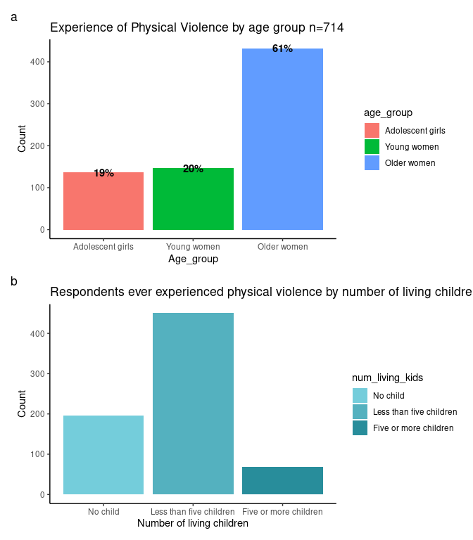

Figure 2: Distribution of physical violence by age group and number of living children

As indicated in Figure 3 below, there is no significant difference between rural and urban women in their experience of physical violence, however, rural women are slightly more likely to experience violence than urban women. Women from Kavango, Omaheke, //Karas and Kunene are more likely to experience physical violence and these regions are mostly in remote areas.

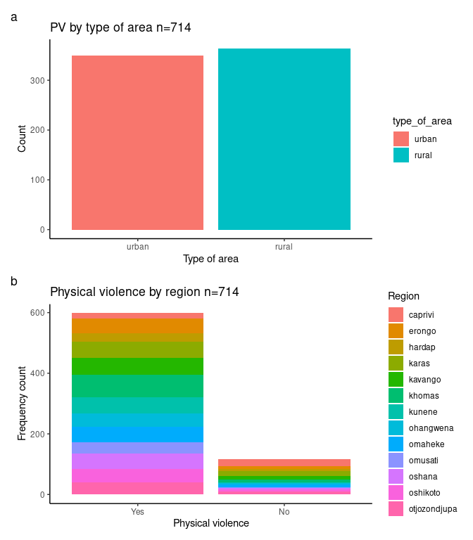

Figure 3: Distribution of physical violence by type of area and region

Women that were never in union are more likely to experience physical violence as presented in Figure 4 below.

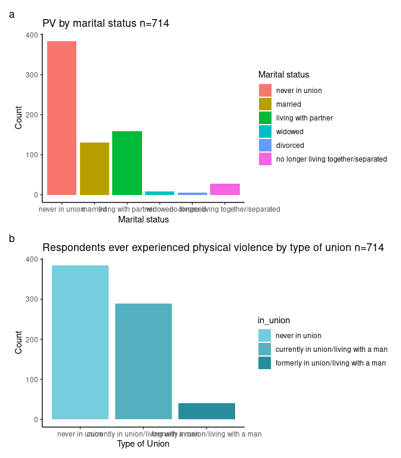

Figure 4: Distribution of physical violence by marital statatus and union

Further, as presented in Figure 5, the survey shows that women with secondary education were more likely to experience physical violence, however there is no clear pattern in the relationship between wealth and the experience of physical violence.

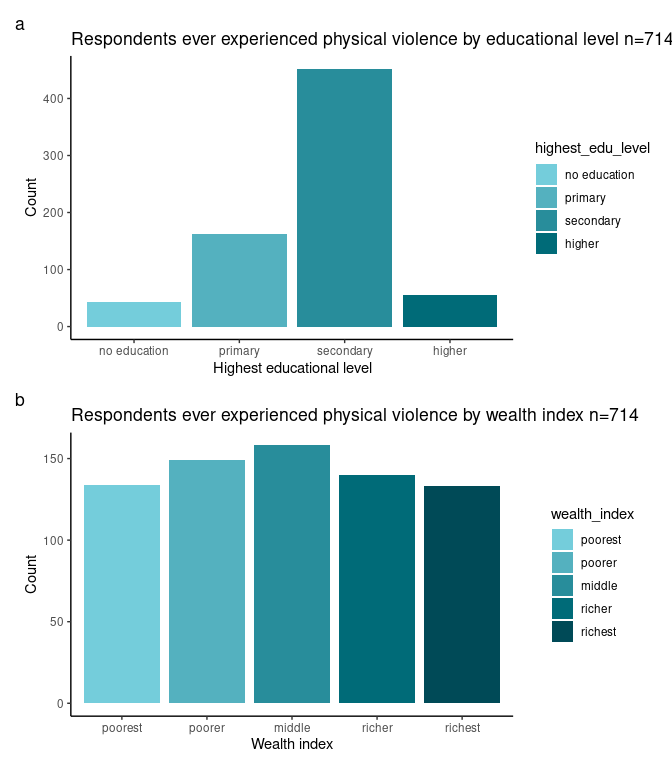

[output not shown]